# R Notebook

### Atribúty faceOffWinPercentage.home a faceOffWinPercentage.away

**charakteristika:** atribút hovorí o percentuálnom počte vyhratých vhadzovaní. Spolu tvorí atribút pre domácich a hostí 100% vhadovaní.

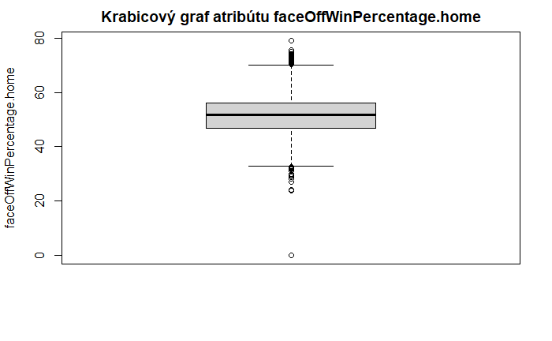

```r
boxplot(df$faceOffWinPercentage.home, ylab= "faceOffWinPercentage.home", main="Krabicový graf atribútu faceOffWinPercentage.home")
```

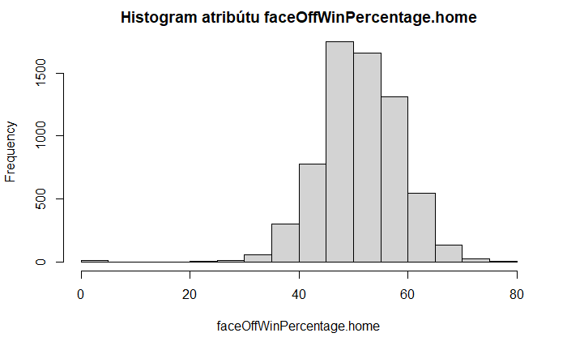

```r
hist(df$faceOffWinPercentage.home, xlab="faceOffWinPercentage.home", main="Histogram atribútu faceOffWinPercentage.home")
```

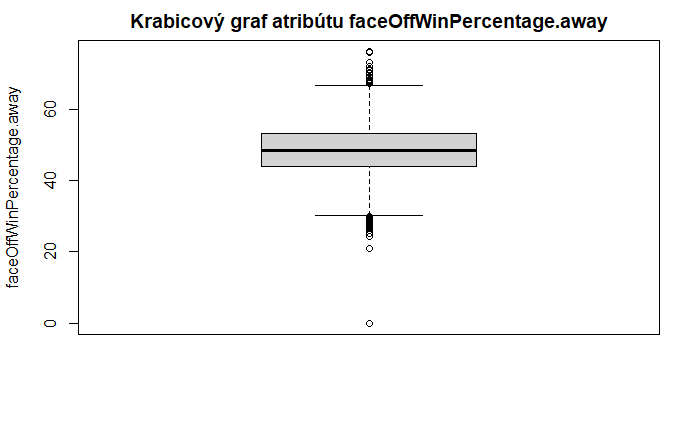

```r
boxplot(df$faceOffWinPercentage.away, ylab="faceOffWinPercentage.away", main="Krabicový graf atribútu faceOffWinPercentage.away")
```

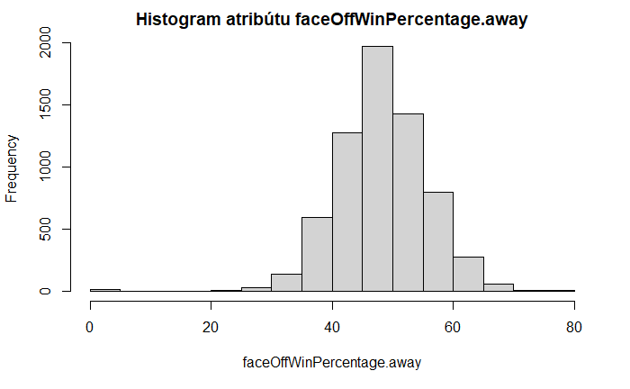

```r
hist(df$faceOffWinPercentage.away, xlab= "faceOffWinPercentage.away", main="Histogram atribútu faceOffWinPercentage.away")
```

Atribút sa veľmi podobá normálnemu rozdeleniu, pričom obsahuje zopár vychýlených hôdnot, ako napr. 0, ktorá logicky nedáva zmysel a budeme sa na ňu musieť pozrieť.

```r
subset(df, faceOffWinPercentage.home == 0)
```

| season | type | goals.away | goals.home | team_id.away | won.away | shots.away | hits.away | pim.away | powerPlayOpportunities.away | powerPlayGoals.away | faceOffWinPercentage.away | giveaways.away | takeaways.away | blocked.away | abbreviation.away | team_id.home | won.home | settled_in | shots.home | hits.home | pim.home | powerPlayOpportunities.home | powerPlayGoals.home | faceOffWinPercentage.home | giveaways.home | takeaways.home | blocked.home | abbreviation.home | save_percentage.home | … |
| --- | --- | --- | --- | --- | --- | --- | --- | --- | --- | --- | --- | --- | --- | --- | --- | --- | --- | --- | --- | --- | --- | --- | --- | --- | --- | --- | --- | --- | --- | --- |
| 20172018 | P | 0 | 0 | 28 | FALSE | 0 | 0 | 0 | 0 | 0 | 0 | 0 | 0 | 0 | SJS | 54 | FALSE | tbc | 0 | 0 | 0 | 0 | 0 | 0 | 0 | 0 | 0 | VGK | NaN | … |
| 20172018 | P | 0 | 0 | 26 | FALSE | 0 | 0 | 0 | 0 | 0 | 0 | 0 | 0 | 0 | LAK | 54 | FALSE | tbc | 0 | 0 | 0 | 0 | 0 | 0 | 0 | 0 | 0 | VGK | NaN | … |
| 20172018 | P | 0 | 0 | 54 | FALSE | 0 | 0 | 0 | 0 | 0 | 0 | 0 | 0 | 0 | VGK | 15 | FALSE | tbc | 0 | 0 | 0 | 0 | 0 | 0 | 0 | 0 | 0 | WSH | NaN | … |
| 20172018 | P | 0 | 0 | 15 | FALSE | 0 | 0 | 0 | 0 | 0 | 0 | 0 | 0 | 0 | WSH | 54 | FALSE | tbc | 0 | 0 | 0 | 0 | 0 | 0 | 0 | 0 | 0 | VGK | NaN | … |
| 20172018 | P | 0 | 0 | 5 | FALSE | 0 | 0 | 0 | 0 | 0 | 0 | 0 | 0 | 0 | PIT | 15 | FALSE | tbc | 0 | 0 | 0 | 0 | 0 | 0 | 0 | 0 | 0 | WSH | NaN | … |
| 20162017 | P | 0 | 0 | 20 | FALSE | 0 | 0 | 0 | 0 | 0 | 0 | 0 | 0 | 0 | CGY | 24 | FALSE | tbc | 0 | 0 | 0 | 0 | 0 | 0 | 0 | 0 | 0 | ANA | NaN | … |
| 20162017 | P | 0 | 0 | 10 | FALSE | 0 | 0 | 0 | 0 | 0 | 0 | 0 | 0 | 0 | TOR | 15 | FALSE | tbc | 0 | 0 | 0 | 0 | 0 | 0 | 0 | 0 | 0 | WSH | NaN | … |
| 20162017 | P | 0 | 0 | 18 | FALSE | 0 | 0 | 0 | 0 | 0 | 0 | 0 | 0 | 0 | NSH | 24 | FALSE | tbc | 0 | 0 | 0 | 0 | 0 | 0 | 0 | 0 | 0 | ANA | NaN | … |
| 20162017 | P | 0 | 0 | 18 | FALSE | 0 | 0 | 0 | 0 | 0 | 0 | 0 | 0 | 0 | NSH | 5 | FALSE | tbc | 0 | 0 | 0 | 0 | 0 | 0 | 0 | 0 | 0 | PIT | NaN | … |
| 20162017 | P | 0 | 0 | 18 | FALSE | 0 | 0 | 0 | 0 | 0 | 0 | 0 | 0 | 0 | NSH | 16 | FALSE | tbc | 0 | 0 | 0 | 0 | 0 | 0 | 0 | 0 | 0 | CHI | NaN | … |

```r
subset(df, faceOffWinPercentage.away == 0)
```

| season | type | goals.away | goals.home | team_id.away | won.away | shots.away | hits.away | pim.away | powerPlayOpportunities.away | powerPlayGoals.away | faceOffWinPercentage.away | giveaways.away | takeaways.away | blocked.away | abbreviation.away | team_id.home | won.home | settled_in | shots.home | hits.home | pim.home | powerPlayOpportunities.home | powerPlayGoals.home | faceOffWinPercentage.home | giveaways.home | takeaways.home | blocked.home | abbreviation.home | save_percentage.home | … |
| --- | --- | --- | --- | --- | --- | --- | --- | --- | --- | --- | --- | --- | --- | --- | --- | --- | --- | --- | --- | --- | --- | --- | --- | --- | --- | --- | --- | --- | --- | --- |
| 20172018 | P | 0 | 0 | 28 | FALSE | 0 | 0 | 0 | 0 | 0 | 0 | 0 | 0 | 0 | SJS | 54 | FALSE | tbc | 0 | 0 | 0 | 0 | 0 | 0 | 0 | 0 | 0 | VGK | NaN | … |
| 20172018 | P | 0 | 0 | 26 | FALSE | 0 | 0 | 0 | 0 | 0 | 0 | 0 | 0 | 0 | LAK | 54 | FALSE | tbc | 0 | 0 | 0 | 0 | 0 | 0 | 0 | 0 | 0 | VGK | NaN | … |
| 20172018 | P | 0 | 0 | 54 | FALSE | 0 | 0 | 0 | 0 | 0 | 0 | 0 | 0 | 0 | VGK | 15 | FALSE | tbc | 0 | 0 | 0 | 0 | 0 | 0 | 0 | 0 | 0 | WSH | NaN | … |
| 20172018 | P | 0 | 0 | 15 | FALSE | 0 | 0 | 0 | 0 | 0 | 0 | 0 | 0 | 0 | WSH | 54 | FALSE | tbc | 0 | 0 | 0 | 0 | 0 | 0 | 0 | 0 | 0 | VGK | NaN | … |
| 20172018 | P | 0 | 0 | 5 | FALSE | 0 | 0 | 0 | 0 | 0 | 0 | 0 | 0 | 0 | PIT | 15 | FALSE | tbc | 0 | 0 | 0 | 0 | 0 | 0 | 0 | 0 | 0 | WSH | NaN | … |
| 20162017 | P | 0 | 0 | 20 | FALSE | 0 | 0 | 0 | 0 | 0 | 0 | 0 | 0 | 0 | CGY | 24 | FALSE | tbc | 0 | 0 | 0 | 0 | 0 | 0 | 0 | 0 | 0 | ANA | NaN | … |
| 20162017 | P | 0 | 0 | 10 | FALSE | 0 | 0 | 0 | 0 | 0 | 0 | 0 | 0 | 0 | TOR | 15 | FALSE | tbc | 0 | 0 | 0 | 0 | 0 | 0 | 0 | 0 | 0 | WSH | NaN | … |
| 20162017 | P | 0 | 0 | 18 | FALSE | 0 | 0 | 0 | 0 | 0 | 0 | 0 | 0 | 0 | NSH | 24 | FALSE | tbc | 0 | 0 | 0 | 0 | 0 | 0 | 0 | 0 | 0 | ANA | NaN | … |
| 20162017 | P | 0 | 0 | 18 | FALSE | 0 | 0 | 0 | 0 | 0 | 0 | 0 | 0 | 0 | NSH | 5 | FALSE | tbc | 0 | 0 | 0 | 0 | 0 | 0 | 0 | 0 | 0 | PIT | NaN | … |
| 20162017 | P | 0 | 0 | 18 | FALSE | 0 | 0 | 0 | 0 | 0 | 0 | 0 | 0 | 0 | NSH | 16 | FALSE | tbc | 0 | 0 | 0 | 0 | 0 | 0 | 0 | 0 | 0 | CHI | NaN | … |

V oboch prípadoch (pri oboch atribútoch) sa jedná o chýbajúce hodnoty záznamov s typom tbc, t.j. preložených alebo zrušených zápasov. Tieto zápasy budú v čistení odstránené, t.j. bude vyriešený problém s touto vychýlenou hodnotou. Ešte môžeme overiť, či súčet atribútov faceOff pre domáci a hosťujúci tím dávajú naozaj hodnotu 100%.

```r
unique(df$faceOffWinPercentage.away + df$faceOffWinPercentage.home == 100)
```

```
[1]  TRUE FALSE    NA
```

Vidíme, ze súčet pravdepodobností nie je vždy rovný 100. Tatkiež dosahuje hodnotu NA v niektorých záznamoch, ale to je očakávané keďže dáta ešte neboli vyčistené. Môžeme sa ale bližšie pozrieť na záznamy, ktoré nedosahujú súčet 100.

```r
subset(df, df$faceOffWinPercentage.away + df$faceOffWinPercentage.home != 100)
```

| season | type | goals.away | goals.home | team_id.away | won.away | shots.away | hits.away | pim.away | powerPlayOpportunities.away | powerPlayGoals.away | faceOffWinPercentage.away | giveaways.away | takeaways.away | blocked.away | abbreviation.away | team_id.home | won.home | settled_in | shots.home | hits.home | pim.home | powerPlayOpportunities.home | powerPlayGoals.home | faceOffWinPercentage.home | giveaways.home | takeaways.home | blocked.home | abbreviation.home | save_percentage.home | … |
| --- | --- | --- | --- | --- | --- | --- | --- | --- | --- | --- | --- | --- | --- | --- | --- | --- | --- | --- | --- | --- | --- | --- | --- | --- | --- | --- | --- | --- | --- | --- |
| 20172018 | P | 0 | 0 | 28 | FALSE | 0 | 0 | 0 | 0 | 0 | 0.0 | 0 | 0 | 0 | SJS | 54 | FALSE | tbc | 0 | 0 | 0 | 0 | 0 | 0.0 | 0 | 0 | 0 | VGK | NaN | … |
| 20172018 | P | 0 | 0 | 26 | FALSE | 0 | 0 | 0 | 0 | 0 | 0.0 | 0 | 0 | 0 | LAK | 54 | FALSE | tbc | 0 | 0 | 0 | 0 | 0 | 0.0 | 0 | 0 | 0 | VGK | NaN | … |
| 20172018 | P | 0 | 0 | 54 | FALSE | 0 | 0 | 0 | 0 | 0 | 0.0 | 0 | 0 | 0 | VGK | 15 | FALSE | tbc | 0 | 0 | 0 | 0 | 0 | 0.0 | 0 | 0 | 0 | WSH | NaN | … |
| 20172018 | P | 0 | 0 | 15 | FALSE | 0 | 0 | 0 | 0 | 0 | 0.0 | 0 | 0 | 0 | WSH | 54 | FALSE | tbc | 0 | 0 | 0 | 0 | 0 | 0.0 | 0 | 0 | 0 | VGK | NaN | … |
| 20172018 | P | 0 | 0 | 5 | FALSE | 0 | 0 | 0 | 0 | 0 | 0.0 | 0 | 0 | 0 | PIT | 15 | FALSE | tbc | 0 | 0 | 0 | 0 | 0 | 0.0 | 0 | 0 | 0 | WSH | NaN | … |
| 20162017 | P | 0 | 0 | 20 | FALSE | 0 | 0 | 0 | 0 | 0 | 0.0 | 0 | 0 | 0 | CGY | 24 | FALSE | tbc | 0 | 0 | 0 | 0 | 0 | 0.0 | 0 | 0 | 0 | ANA | NaN | … |
| 20162017 | P | 0 | 0 | 10 | FALSE | 0 | 0 | 0 | 0 | 0 | 0.0 | 0 | 0 | 0 | TOR | 15 | FALSE | tbc | 0 | 0 | 0 | 0 | 0 | 0.0 | 0 | 0 | 0 | WSH | NaN | … |
| 20162017 | P | 0 | 0 | 18 | FALSE | 0 | 0 | 0 | 0 | 0 | 0.0 | 0 | 0 | 0 | NSH | 24 | FALSE | tbc | 0 | 0 | 0 | 0 | 0 | 0.0 | 0 | 0 | 0 | ANA | NaN | … |
| 20162017 | P | 0 | 0 | 18 | FALSE | 0 | 0 | 0 | 0 | 0 | 0.0 | 0 | 0 | 0 | NSH | 5 | FALSE | tbc | 0 | 0 | 0 | 0 | 0 | 0.0 | 0 | 0 | 0 | PIT | NaN | … |
| 20162017 | P | 0 | 0 | 18 | FALSE | 0 | 0 | 0 | 0 | 0 | 0.0 | 0 | 0 | 0 | NSH | 16 | FALSE | tbc | 0 | 0 | 0 | 0 | 0 | 0.0 | 0 | 0 | 0 | CHI | NaN | … |

[output cut: 1 more lines]

Jedná sa o našich klasických 10 nadbytočných záznamov. Zaujímavé však je, že sa tu naskytuje aj 11-ty záznam z reálneho zápasu medzi San Jose Sharks a Montreal Canadiens.

```r
38.8 + 61.3
```

```
[1] 100.1
```

Tento zápas presahuje maximálnu úspešnosť vhadzovaní o 0.1%. Toto sa pravdepodobne stalo kvôli zaokrúhľovaniu úspešností vhadzovaní jednotlivých tímov. Nejedná sa však o nejakú kritickú chybu, reálne to na dáta a výstup projektu nebude mať žiaden dopad a preto tento problém riešiť nebude potrebné (dalo by sa prípadne odpočítať od každej pravdepodobnosti -0.05 tak, aby bola výsledná hodnota 100).

### Atribúty giveaways.home a giveaways.away

**charakteristika:** atribút reprezentujúci odovzdané puky súperiacemu tímu bez súboja. Takýchto situácií sa v zápasoch vyskytuje viacero a nie sú nezvyčajným javom zápasu NHL.

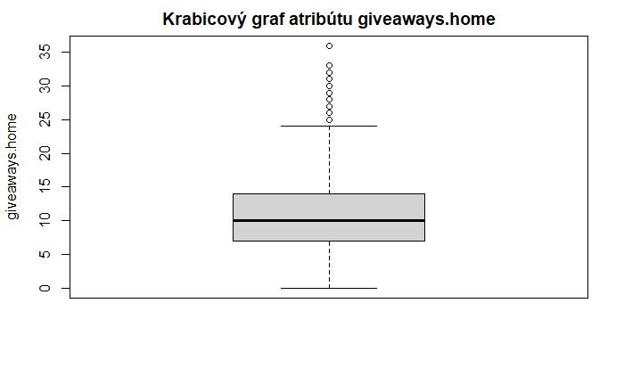

```r
boxplot(df$giveaways.home, ylab = "giveaways.home", main="Krabicový graf atribútu giveaways.home")
```

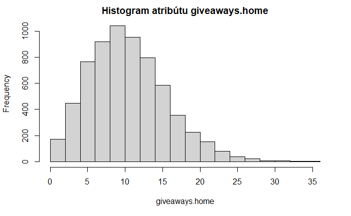

```r
hist(df$giveaways.home, xlab = "giveaways.home", main="Histogram atribútu giveaways.home")
```

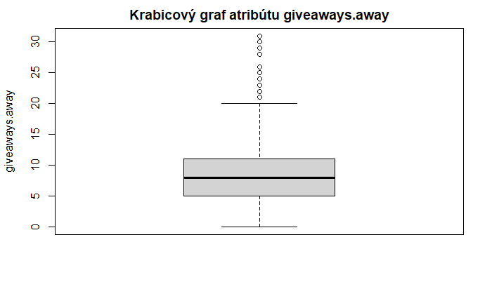

```r
boxplot(df$giveaways.away, ylab = "giveaways.away", main="Krabicový graf atribútu giveaways.away")
```

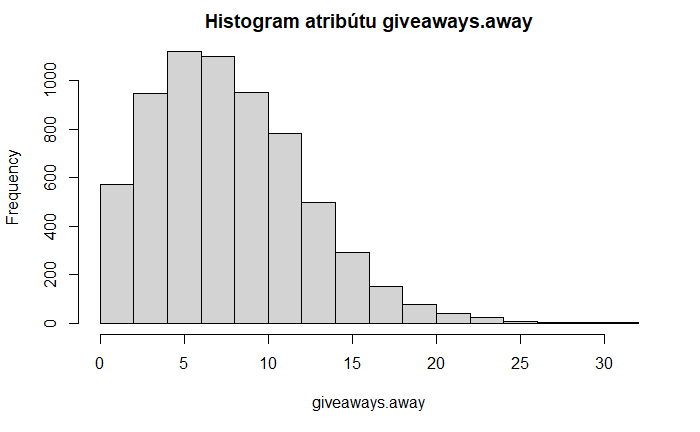

```r
hist(df$giveaways.away, xlab = "giveaways.away", main="Histogram atribútu giveaways.away")
```

Hodnoty jemne pripomínajú normálne rozdelenie, no reálne sa bude jednať o distribúciu naklonenú vpravo. Taktiež je tam veľa vychýleých hodnôt, ktoré však nemusia znamenať chyby merania. Atribút nebudeme analyzovať podrobnejšie z dôvodu, že pre našu prácu ho nepovažujeme za kľúčový.

### Atribúty takeaways.home a takeaways.away

**charakteristika:** atribút, ktorý reprezentuje počet odobraných pukov súperiacemu tímu. Tento atribút nie je komplementom vyššie spomenutého atribútu odovzdania pukov.

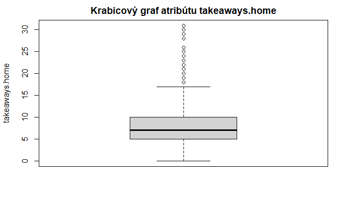

```r
boxplot(df$takeaways.home, ylab = "takeaways.home", main="Krabicový graf atribútu takeaways.home")
```

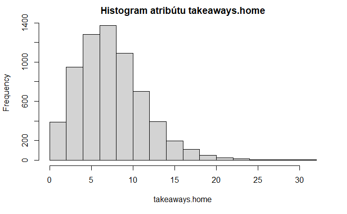

```r
hist(df$takeaways.home, xlab = "takeaways.home", main="Histogram atribútu takeaways.home")
```

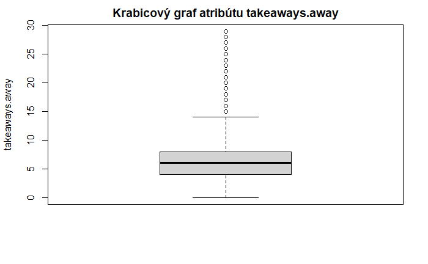

```r
boxplot(df$takeaways.away, ylab = "takeaways.away", main="Krabicový graf atribútu takeaways.away")
```

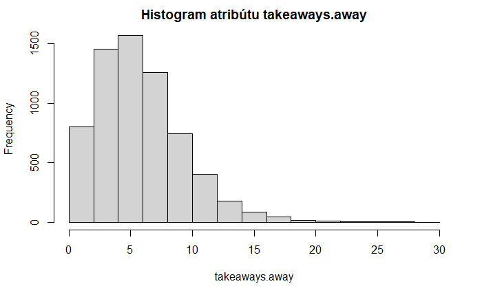

```r
hist(df$takeaways.away, xlab = "takeaways.away", main="Histogram atribútu takeaways.away")
```

Na histograme môžeme vidieť, že sa jedná o distribúciu naklonenú vpravo. Taktiež je tam dosť vychýleých hodnôt, ktoré však opäť nemusia (a pravdepodobne ani nebudú) znamenať chyby merania. Atribút nebudeme analyzovať podrobnejšie z dôvodu, že pre našu prácu ho nepovažujeme za kľúčový (má maximálne len situačné využitie).

### Atribúty blocked.home a blocked.away

**charakteristika:** atribút súčtu zablokovaných striel na bránu. hráčmi, inými ako brankár. To znamená, že hráč zablokuje strelu na bránu hokejkou, korčuľou, alebo telom a puk sa vôbec nedostane k brankárovi. Zabkovania strely nie sú nezvyčajné v NHL, ale nevyskytujú sa vo veľkých počtoch, ako napr. strely na bránku.

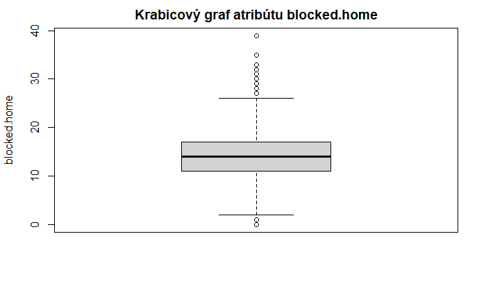

```r
boxplot(df$blocked.home, ylab="blocked.home", main="Krabicový graf atribútu blocked.home")
```

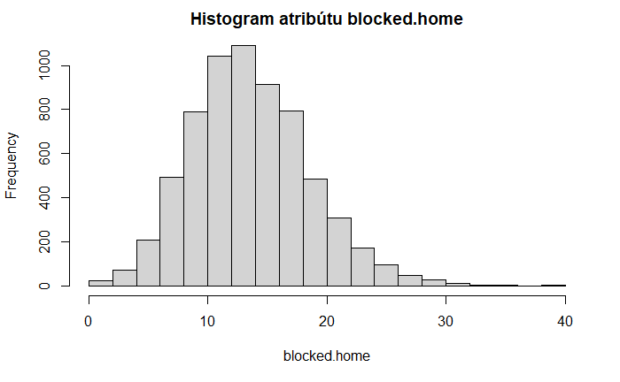

```r
hist(df$blocked.home, xlab="blocked.home", main="Histogram atribútu blocked.home")
```

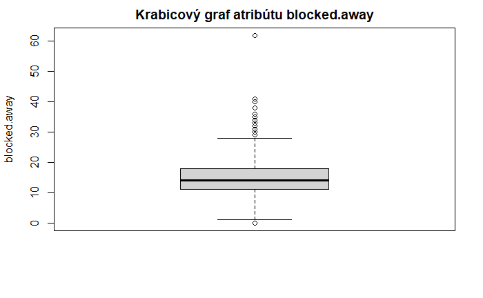

```r
boxplot(df$blocked.away, ylab="blocked.away", main="Krabicový graf atribútu blocked.away")
```

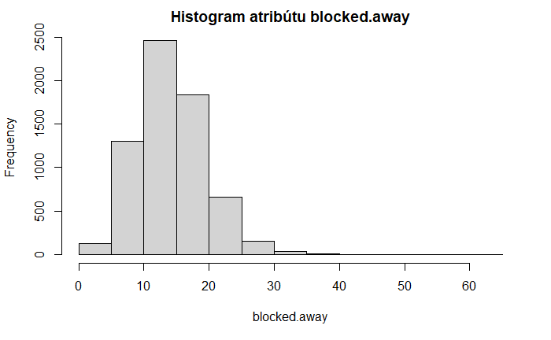

```r
hist(df$blocked.away, xlab="blocked.away", main="Histogram atribútu blocked.away")
```

Hodnoty atribútu veľmi pripomínajú normálne rozdeleni, ale vidíme aj zopár vychýlených hodnôt, čo môže byť z dôvodu dlhší hier, napr. kvôli predĺženiu. Atribút **blocked.away** obsahuje jednu výrazne vychýlenú hodnotu, ktorú bude vhodné riešiť pri čistení dát. Distribúcia pripomína normálne rozdelenie, nakreslíme si QQ-plot a pozrieme sa na zhodu s krivkou teoretického normálneho rozdelenia.

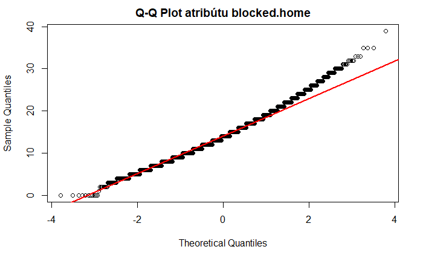

```r
qqnorm(df$blocked.home, main="Q-Q Plot atribútu blocked.home")
qqline(df$blocked.home, col = "red", lwd = 2)
```

Atribút sa odkláňa od normálnej krivky pri hodnotách >= 20.

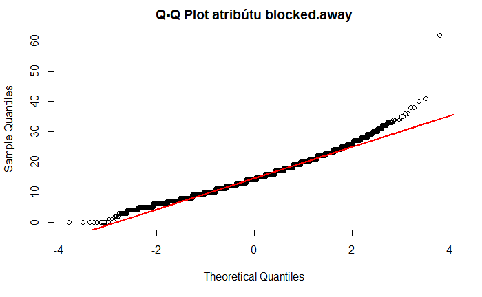

```r
qqnorm(df$blocked.away, main="Q-Q Plot atribútu blocked.away")
qqline(df$blocked.away, col = "red", lwd = 2)
```

Atribút sa odkláňa od normálnej krivky pri hodnotách >= 20. Obsahuje jednu výrazne vychýlenú hodnotu (>60). Túto hodnotu bude vhodné redukovať tak, aby nehrozilo skreslenie výsledkov. Vykonáme ešte Shapiro-Wilkov test normality aby sme sa uistili, že atribúty nepochádzajú z normálneho rozdelenia.

Grafy indikujú signifikantnú podobnosť s normálnym rozdelením. Bude preto vhodné vykonať Shapiro-Wilkov test normality, pre ktorý je potrebné vybrať reprezentatívnu vzorku o veľkosti 1000.

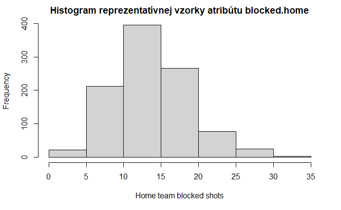

```r
sample <- sample_n(df, 1000)
hist(sample$blocked.home, xlab="Home team blocked shots", main="Histogram reprezentatívnej vzorky atribútu blocked.home")
```

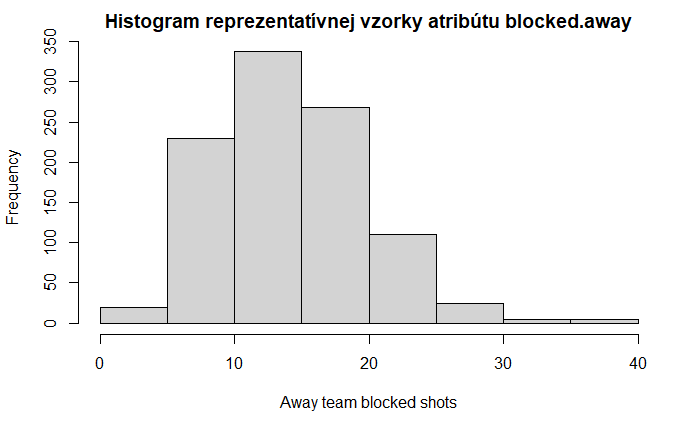

```r
hist(sample$blocked.away, xlab="Away team blocked shots", main="Histogram reprezentatívnej vzorky atribútu blocked.away")
```

```r
cat("Štatistika blocked.home\n")
```

```
Štatistika blocked.home
```

```r
summary(df$blocked.home)
```

```
   Min. 1st Qu.  Median    Mean 3rd Qu.    Max.    NA's
   0.00   11.00   14.00   14.09   17.00   39.00       4
```

```r
cat("Štatistika vzorky blocked.home\n")
```

```
Štatistika vzorky blocked.home
```

```r
summary(sample$blocked.home)
```

```
   Min. 1st Qu.  Median    Mean 3rd Qu.    Max.    NA's
   0.00   11.00   14.00   14.25   18.00   35.00       1
```

```r
cat("Štatistika blocked.away\n")
```

```
Štatistika blocked.away
```

```r
summary(df$blocked.away)
```

```
   Min. 1st Qu.  Median    Mean 3rd Qu.    Max.    NA's
   0.00   11.00   14.00   14.68   18.00   62.00       4
```

```r
cat("Štatistika vzorky blcoked.away\n")
```

```
Štatistika vzorky blcoked.away
```

```r
summary(sample$blocked.away)
```

```
   Min. 1st Qu.  Median    Mean 3rd Qu.    Max.    NA's
   0.00   11.00   14.00   14.67   18.00   38.00       1
```

Vzorka má podobnú varianciu ako pôvodný dataset, preto na nej vykonáme test normality s hladinou p = 0.05.

```r
shapiro.test(sample$blocked.home)
```

```
    Shapiro-Wilk normality test

data:  sample$blocked.home
W = 0.98171, p-value = 7.07e-10
```

```r
shapiro.test(sample$blocked.away)
```

```
    Shapiro-Wilk normality test

data:  sample$blocked.away
W = 0.97375, p-value = 1.849e-12
```

Test v oboch prípadoch zamietame, atribút nepochádza z normálneho rozdelenia. Vychýlenú hodnotu v atribúte **blocked.away** bude vhodné pri čistení dát riešiť.

### Atribúty abbreviation.home a abbreviation.away

**charakteristika:** atribút, ktoréh hodnoty obsahujú iba tri písmená a reprezentuje skratkú tímov., ktoré prosti sebe nastúpili v zápase. Pre nami vybrané sezóny bolo v NHL 31 tímov a teda má tento atribút 31 unikátnych hodnôt.

Tento atribút ma iba čisto informatívny charakter, môžeme akurát overiť či sa počet skratiek tímov reálne rovná počtu tímov patriacich do súťaže NHL (čiže 31 tímov).

```r
length(unique(df$abbreviation.away))
```

```
[1] 32
```

```r
length(unique(df$abbreviation.home))
```

```
[1] 32
```

Zistili sme, že v oboch atribútoch je o jednu hodnotu navyše. Pozrieme sa teda na hodnoty a skúsime nájsť vinníka.

```r
unique(df$abbreviation.away)
```

```
 [1] "PHI" "ANA" "COL" "WPG" "CGY" "WSH" "TOR" "VAN" "CBJ" "EDM" "NYI" "CHI" "PIT" "TBL" "BOS"
[16] "NJD" "OTT" "MTL" "LAK" "FLA" "CAR" "SJS" "MIN" "NYR" "DAL" "DET" "BUF" "ARI" "STL" "NSH"
[31] "VGK" NA
```

PHI - Philadelphia Flyers

ANA - Annaheim Ducks

COL - Colorado Avalanche

WPG - Winnipeg Jets

CGY - Calgary Flames

WSH - Washington Capitals

TOR - Toronto Maple Leafs

VAN - Vancouver Canucks

CBJ - Columbus Blue Jackets

EDM - Edmonton Oilers

NYI - New York Islanders

CHI - Chicago Blackhawks

PIT - Pittsburg Penguins

TBL - Tamba Bay Lightning

BOS - Boston Bruins

NJD - New Jersey Devils

OTT - Ottawa Senators

MTL - Montreal Canadiens

LAK - Los Angeles Kings

FLA - Florida Panthers

CAR - Carolina Hurricanes

SJS - San Jose Sharks

MIN - Minnesota Wild

NYR - New York Rangers

DAL - Dallas Stars

DET - Detroit Red Wings

BUF - Buffalo Sabres

ARI - Arizone Coyotes

STL - Saint Louis Blues

NSH - Nashville Predators

VGK - Las Vegas Golden Knights

NA - hodnota ktorú nadobúda abbreviation pri type A - zápasy mimo NHL

Všetky hodnoty boli popísané a taktiež bol vysvetlený o jeden väčší počet - ten bude pri čistení dát odstránený. Tento atribút však z hľadiska štatistiky neprináša žiadnu dodatočnú hodnotu, slúži iba na priradenie zápasov k reálnym názvom tímov dodatočne ako k iba im ID-čkam.

### Atribúty settled_in

**charakteristika:** atribút, ktorý ukazuje ako skončil zápas. V NHL môže zápas skončiť viacerými spôsobmi: v riadnom hracom čase, v predĺžení, po nájazdoch (v starších sezónach), alebo z netradičných dôvodov (roztopenie ľadu, výpadok elektrického prúsu, …).

```r
unique(df$settled_in)
```

```
[1] "REG" "OT"  "tbc"
```

Tento atribút nadobúda 3 hodnoty - REG, OT a tbc. REG - rozhodnutý zápas v riadnom hraciom čase OT - zápas rozhodnutý v predĺžení tbc - pravdepodobne zrušený zápas

Keďže si niesme istý, čo reprezentuje hodnota atribútu “tbc”, vypíŠeme si záznamy ktoré ju obsahujú.

```r
subset(df, settled_in=='tbc')
```

| season | type | goals.away | goals.home | team_id.away | won.away | shots.away | hits.away | pim.away | powerPlayOpportunities.away | powerPlayGoals.away | faceOffWinPercentage.away | giveaways.away | takeaways.away | blocked.away | abbreviation.away | team_id.home | won.home | settled_in | shots.home | hits.home | pim.home | powerPlayOpportunities.home | powerPlayGoals.home | faceOffWinPercentage.home | giveaways.home | takeaways.home | blocked.home | abbreviation.home | save_percentage.home | … |
| --- | --- | --- | --- | --- | --- | --- | --- | --- | --- | --- | --- | --- | --- | --- | --- | --- | --- | --- | --- | --- | --- | --- | --- | --- | --- | --- | --- | --- | --- | --- |
| 20172018 | P | 0 | 0 | 28 | FALSE | 0 | 0 | 0 | 0 | 0 | 0.0 | 0 | 0 | 0 | SJS | 54 | FALSE | tbc | 0 | 0 | 0 | 0 | 0 | 0.0 | 0 | 0 | 0 | VGK | NaN | … |
| 20172018 | P | 0 | 0 | 28 | FALSE | NA | NA | NA | NA | NA | NA | NA | NA | NA | SJS | 24 | FALSE | tbc | NA | NA | NA | NA | NA | NA | NA | NA | NA | ANA | NA | … |
| 20172018 | P | 0 | 0 | 26 | FALSE | 0 | 0 | 0 | 0 | 0 | 0.0 | 0 | 0 | 0 | LAK | 54 | FALSE | tbc | 0 | 0 | 0 | 0 | 0 | 0.0 | 0 | 0 | 0 | VGK | NaN | … |
| 20172018 | P | 0 | 0 | 52 | FALSE | NA | NA | NA | NA | NA | NA | NA | NA | NA | WPG | 54 | FALSE | tbc | NA | NA | NA | NA | NA | NA | NA | NA | NA | VGK | NA | … |
| 20172018 | P | 0 | 0 | 54 | FALSE | NA | NA | NA | NA | NA | NA | NA | NA | NA | VGK | 52 | FALSE | tbc | NA | NA | NA | NA | NA | NA | NA | NA | NA | WPG | NA | … |
| 20172018 | P | 0 | 0 | 54 | FALSE | 0 | 0 | 0 | 0 | 0 | 0.0 | 0 | 0 | 0 | VGK | 15 | FALSE | tbc | 0 | 0 | 0 | 0 | 0 | 0.0 | 0 | 0 | 0 | WSH | NaN | … |
| 20172018 | P | 0 | 0 | 15 | FALSE | 0 | 0 | 0 | 0 | 0 | 0.0 | 0 | 0 | 0 | WSH | 54 | FALSE | tbc | 0 | 0 | 0 | 0 | 0 | 0.0 | 0 | 0 | 0 | VGK | NaN | … |
| 20172018 | P | 0 | 0 | 5 | FALSE | 0 | 0 | 0 | 0 | 0 | 0.0 | 0 | 0 | 0 | PIT | 15 | FALSE | tbc | 0 | 0 | 0 | 0 | 0 | 0.0 | 0 | 0 | 0 | WSH | NaN | … |
| 20162017 | P | 0 | 0 | 20 | FALSE | 0 | 0 | 0 | 0 | 0 | 0.0 | 0 | 0 | 0 | CGY | 24 | FALSE | tbc | 0 | 0 | 0 | 0 | 0 | 0.0 | 0 | 0 | 0 | ANA | NaN | … |
| 20162017 | P | 0 | 0 | 10 | FALSE | 0 | 0 | 0 | 0 | 0 | 0.0 | 0 | 0 | 0 | TOR | 15 | FALSE | tbc | 0 | 0 | 0 | 0 | 0 | 0.0 | 0 | 0 | 0 | WSH | NaN | … |

[output cut: 9 more lines]

V drtivej väčšine prípadov sa jedná o zrušené zápasy - vyskytujú sa tu však aj zápasy, ktorých štatistiky nadobúdajú hodnoty odlišné od 0 - vo všetkých prípadoch majú tieto zápasy však type = A, čo sme už v predošlej analýze atribútu type usúdili, že sa nejedná o valídne NHL zápasy a preto budú z datasetu pri čistení odstránené. Vieme povedať, že všetky zápasy ktoré nadobúdajú hodnotu tbc budú teda odstránené - ani jeden totižto neprináša pridanú hodnotu (0-vé hodnoty relevantných štatistík alebo zápasy mimo súťaže NHL).

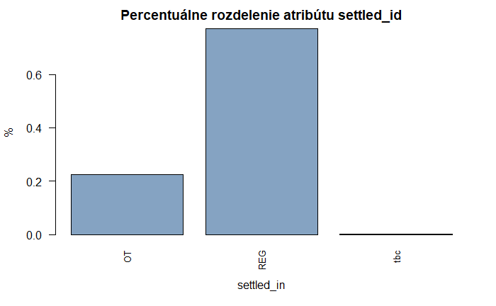

```r
barplot(prop.table(table(df$settled_in)), las=2, cex.names=.8, col=rgb(0.2,0.4,0.6,0.6), ylab="%", xlab="settled_in", main="Percentuálne rozdelenie atribútu settled_id")
```

Z grafu vidíme, že cca 20% zápasov je ukončených mimo riadneho hracieho času (v predĺžení). Percentuálny pomer hodnoty tbc je zanedbateľný. Okolo 80% zápasov je tým pádom rozhodnutých v riadnom hracom čase. Pri párovej analýze môže byť dodatočne zaujímave pozrieť sa, koľko zápasov play-off sa končí v predĺžení oproti zápasom regulárnej sezóny (predpokladáme že v play-off bývajú zápasy vyrovnanejšie a tým pádom je častejšie po riadnom hracom čase remízový stav).

Keďže tento atribút reálne nadobúda iba 2 hodnoty, bude možné ho pri fáze transformácie dát konvertovať na binárny atribút - ten je jednoduchšie strojovo spracovateľný a je moŽné sledovať aj závislosti s inými numerickými atribútmi napr. pomocou korelácií alebo logistickej regresie.